# Q & K Box 10.3

Bleeker et al. (2017) examined variability in reproductive characteristics of a goby (*Neogonius melanostomus*) along the Rhine River in Europe. They had five sampling sites along the Rhine and imagine that the five sites represented a random sample from a population of possible sites. At each site they had between seven and 22 fish; the response variable was gonad mass and the covariate was body length (centered as a body length of zero is nonsensical). Our interest is how the relationship between gonad mass and body length varied across the random effect of site.

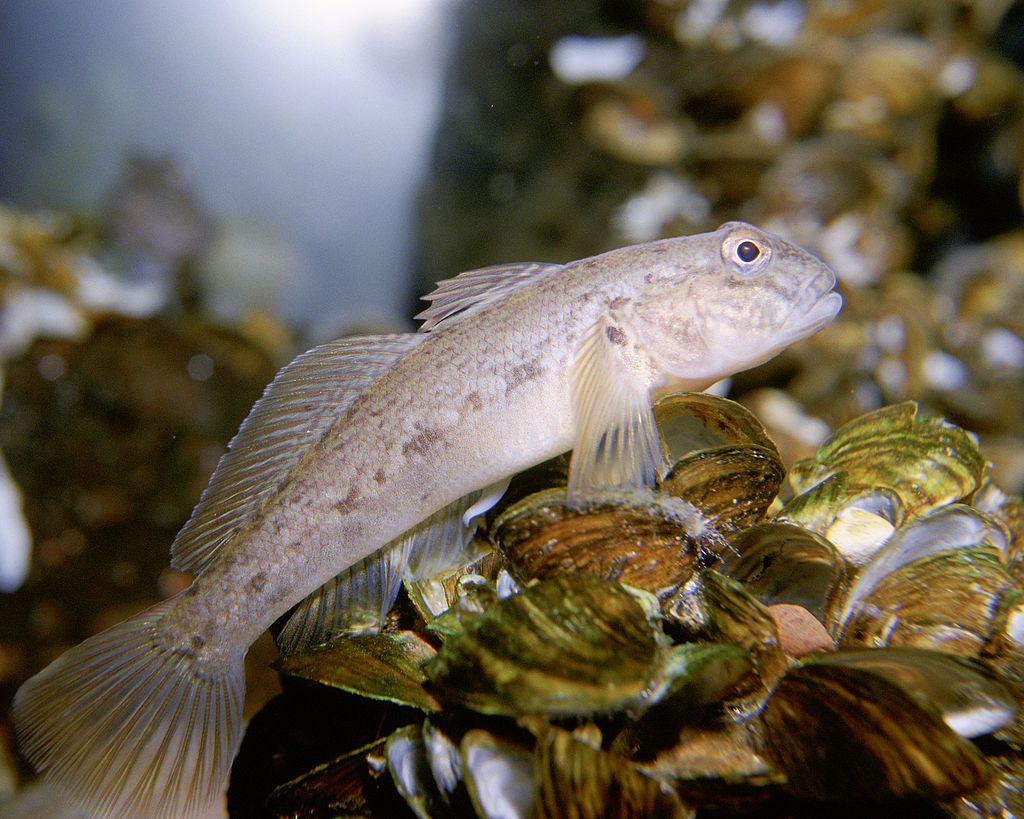

Eric Engbretson, U.S. Fish and Wildlife Service, Public domain, via Wikimedia Commons

The paper is here

Bleeker, K., de Jong, K., van Kessel, N., Hinde, C. A. & Nagelkerke, L. A. J. (2017). Evidence for ontogenetically and morphologically distinct alternative reproductive tactics in the invasive Round Goby Neogobius melanostomus. *PLoS One*, 12.

## Preliminaries

First, load the required packages (afex, car, lattice, lme4, lmerTest, nlme, VCA)

Import bleeker data file (bleeker1.csv)

```r
bleeker1 <- read.csv("../data/bleeker1.csv")
bleeker1
```

| river | tl | gm |
| --- | --- | --- |
| Downstream Waal | 7.0 | 0.4323 |
| Downstream Waal | 7.4 | 0.4799 |
| Downstream Waal | 5.4 | 0.1055 |
| Downstream Waal | 6.8 | 0.1588 |
| Downstream Waal | 7.5 | 0.6857 |
| Downstream Waal | 10.0 | 0.4505 |
| Downstream Waal | 8.5 | 0.1776 |
| Downstream Waal | 11.9 | 1.0306 |
| Downstream Waal | 10.5 | 0.0824 |
| Downstream Waal | 11.0 | 0.2346 |

[output cut: 59 more lines]

Set contrasts from afex

```r
set_sum_contrasts()
```

```
## setting contr.sum globally: options(contrasts=c('contr.sum', 'contr.poly'))
```

### Focus on models with covariate

Check linearity and then variances

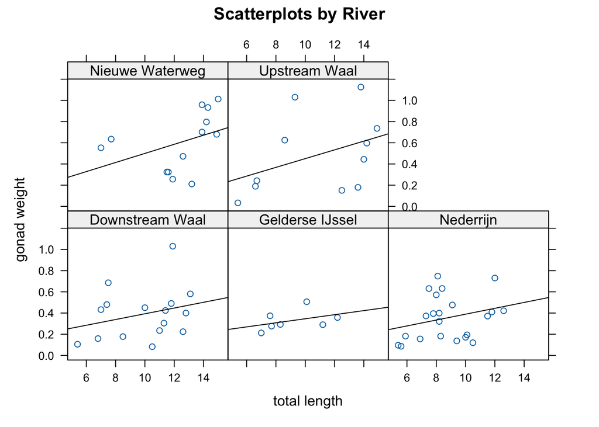

```r
panel.smoother <- function(x, y) {
  panel.xyplot(x, y)
  panel.lmline(x, y)
}
xyplot(gm~tl|river,main="Scatterplots by River", ylab="gonad weight", xlab="total length", panel=panel.smoother, bleeker1)
```

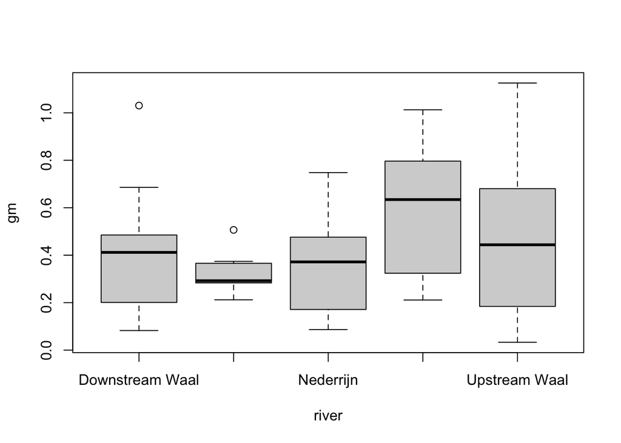

```r
# check boxplots - variance difference for gm but not related to mean
boxplot(gm~river, bleeker1)
```

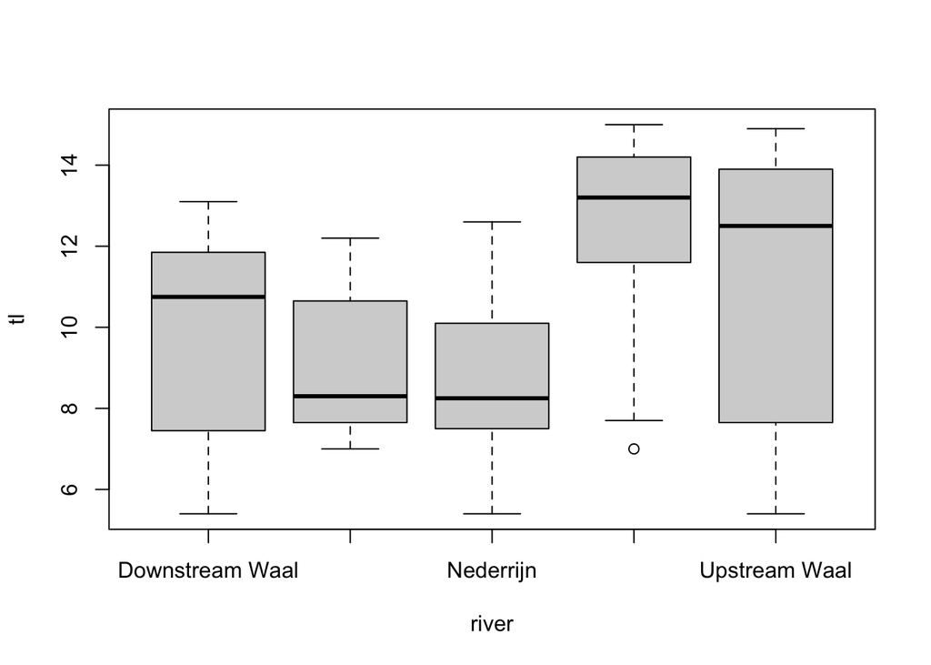

```r
boxplot(tl~river, bleeker1)
```

Linearity seems OK and variance difference for gonad mass but not related to mean

### Fit random coefficients model

```r
bleeker.lmer1 <- lmer(gm~tl +(tl|river), REML=TRUE, bleeker1)
```

```
## boundary (singular) fit: see help('isSingular')
```

```r
summary(bleeker.lmer1)
```

```
## Linear mixed model fit by REML. t-tests use Satterthwaite's method [
## lmerModLmerTest]
## Formula: gm ~ tl + (tl | river)
##    Data: bleeker1
##
## REML criterion at convergence: 8.6
##
## Scaled residuals:
##     Min      1Q  Median      3Q     Max
## -1.6723 -0.6896 -0.2498  0.5697  2.6659
##
## Random effects:
##  Groups   Name        Variance  Std.Dev.  Corr
##  river    (Intercept) 1.267e-05 0.0035598
##           tl          2.036e-07 0.0004513 -1.00
##  Residual             5.687e-02 0.2384758
## Number of obs: 69, groups:  river, 5
##
## Fixed effects:
##              Estimate Std. Error        df t value Pr(>|t|)
## (Intercept) -0.002204   0.108021 64.778750  -0.020 0.983788
## tl           0.042661   0.010310 60.038508   4.138 0.000111 ***
## ---
## Signif. codes:  0 '***' 0.001 '**' 0.01 '*' 0.05 '.' 0.1 ' ' 1
##
## Correlation of Fixed Effects:
##    (Intr)
## tl -0.964
## optimizer (nloptwrap) convergence code: 0 (OK)
## boundary (singular) fit: see help('isSingular')
```

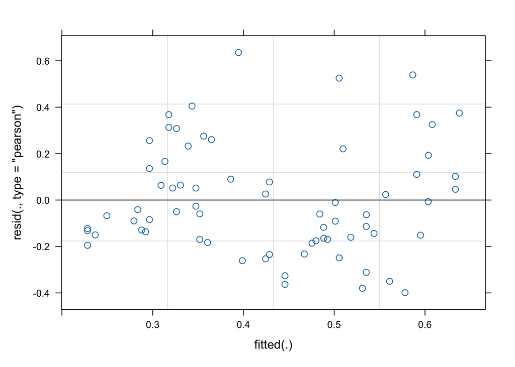

```r
plot(bleeker.lmer1)
```

```r
isSingular(bleeker.lmer1)
```

```
## [1] TRUE
```

### Remove correlation between random effects

```r
bleeker.lmer2 <- lmer(gm~tl +(tl||river), REML=TRUE, bleeker1)
```

```
## boundary (singular) fit: see help('isSingular')
```

```r
summary(bleeker.lmer2)
```

```
## Linear mixed model fit by REML. t-tests use Satterthwaite's method [
## lmerModLmerTest]
## Formula: gm ~ tl + (tl || river)
##    Data: bleeker1
##
## REML criterion at convergence: 8.6
##
## Scaled residuals:
##     Min      1Q  Median      3Q     Max
## -1.6723 -0.6894 -0.2498  0.5698  2.6659
##
## Random effects:
##  Groups   Name        Variance Std.Dev.
##  river    (Intercept) 0.00000  0.0000
##  river.1  tl          0.00000  0.0000
##  Residual             0.05687  0.2385
## Number of obs: 69, groups:  river, 5
##
## Fixed effects:
##              Estimate Std. Error        df t value Pr(>|t|)
## (Intercept) -0.002245   0.108005 67.000000  -0.021    0.983
## tl           0.042666   0.010307 67.000000   4.139 9.95e-05 ***
## ---
## Signif. codes:  0 '***' 0.001 '**' 0.01 '*' 0.05 '.' 0.1 ' ' 1
##
## Correlation of Fixed Effects:
##    (Intr)
## tl -0.964
## optimizer (nloptwrap) convergence code: 0 (OK)
## boundary (singular) fit: see help('isSingular')
```

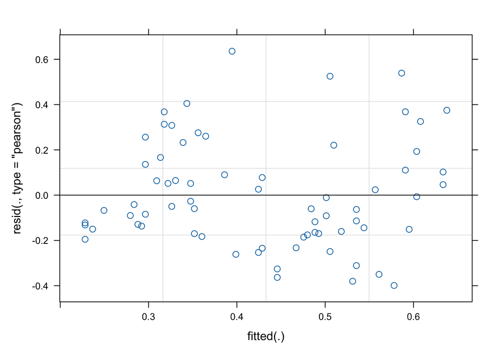

```r
plot(bleeker.lmer2)
```

```r
isSingular(bleeker.lmer2)
```

```
## [1] TRUE
```

Removing correlation makes little difference to model’s fit

### Singular warning so try with centered covariate

```r
bleeker1$ctl <- scale(bleeker1$tl, center=TRUE, scale=FALSE)
bleeker.lmer3 <- lmer(gm~ctl +(ctl||river), REML=TRUE, bleeker1)
```

```
## boundary (singular) fit: see help('isSingular')
```

```r
summary(bleeker.lmer3)
```

```
## Linear mixed model fit by REML. t-tests use Satterthwaite's method [
## lmerModLmerTest]
## Formula: gm ~ ctl + (ctl || river)
##    Data: bleeker1
##
## REML criterion at convergence: 8.6
##
## Scaled residuals:
##     Min      1Q  Median      3Q     Max
## -1.6723 -0.6894 -0.2498  0.5698  2.6659
##
## Random effects:
##  Groups   Name        Variance Std.Dev.
##  river    (Intercept) 0.00000  0.0000
##  river.1  ctl         0.00000  0.0000
##  Residual             0.05687  0.2385
## Number of obs: 69, groups:  river, 5
##
## Fixed effects:
##             Estimate Std. Error       df t value Pr(>|t|)
## (Intercept)  0.42874    0.02871 67.00000  14.934  < 2e-16 ***
## ctl          0.04267    0.01031 67.00000   4.139 9.95e-05 ***
## ---
## Signif. codes:  0 '***' 0.001 '**' 0.01 '*' 0.05 '.' 0.1 ' ' 1
##
## Correlation of Fixed Effects:
##     (Intr)
## ctl 0.000
## optimizer (nloptwrap) convergence code: 0 (OK)
## boundary (singular) fit: see help('isSingular')
```

```r
isSingular(bleeker.lmer3)
```

```
## [1] TRUE
```

**Correlation between random effects reduced but still warning about singularity**

### Proceeded to compare random coefficients and random intercepts model with nlme. Also generate AICc for each model

```r
bleeker.lme1 <- lme(fixed=gm~ctl, random=~1|river/ctl, method="REML", bleeker1)
bleeker.lme2 <- lme(fixed=gm~ctl, random=~1|river, method="REML", bleeker1)
anova(bleeker.lme1, bleeker.lme2)
```

|  | call | Model | df | AIC | BIC | logLik | Test | L.Ratio | p-value |
| --- | --- | --- | --- | --- | --- | --- | --- | --- | --- |
| bleeker.lme1 | lme.formula(fixed = gm ~ ctl, data = bleeker1, random = ~1 \| river/ctl, method = "REML") | 1 | 5 | 17.77947 | 28.80293 | -3.889733 |  | NA | NA |
| bleeker.lme2 | lme.formula(fixed = gm ~ ctl, data = bleeker1, random = ~1 \| river, method = "REML") | 2 | 4 | 16.56929 | 25.38806 | -4.284646 | 1 vs 2 | 0.7898262 | 0.3741527 |

```r
#AICc
AICc(bleeker.lme1)
```

```
## [1] 18.73185
```

```r
AICc(bleeker.lme2)
```

```
## [1] 17.19429
```

Difference in fit of the two models is not great, so we will ignore the random coefficients (river x length)

### Fit random intercept model with lmer

```r
bleeker.lmer4 <- lmer(gm~ctl +(1|river), REML=TRUE, bleeker1)
```

```
## boundary (singular) fit: see help('isSingular')
```

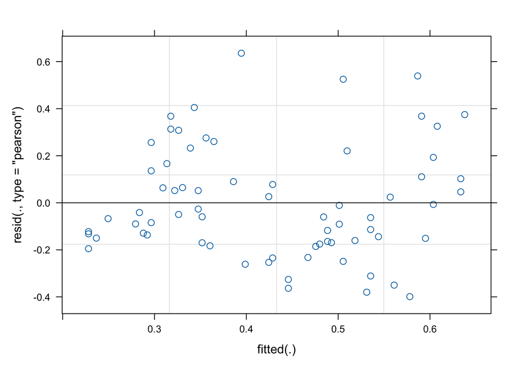

```r
plot(bleeker.lmer4)
```

Residuals look fine

```r
summary(bleeker.lmer4, ddf="Kenward-Roger")
```

```
## Linear mixed model fit by REML. t-tests use Kenward-Roger's method [
## lmerModLmerTest]
## Formula: gm ~ ctl + (1 | river)
##    Data: bleeker1
##
## REML criterion at convergence: 8.6
##
## Scaled residuals:
##     Min      1Q  Median      3Q     Max
## -1.6723 -0.6894 -0.2498  0.5698  2.6659
##
## Random effects:
##  Groups   Name        Variance Std.Dev.
##  river    (Intercept) 0.00000  0.0000
##  Residual             0.05687  0.2385
## Number of obs: 69, groups:  river, 5
##
## Fixed effects:
##             Estimate Std. Error       df t value Pr(>|t|)
## (Intercept)  0.42874    0.03074  2.77327  13.946 0.001190 **
## ctl          0.04267    0.01170 36.24997   3.648 0.000825 ***
## ---
## Signif. codes:  0 '***' 0.001 '**' 0.01 '*' 0.05 '.' 0.1 ' ' 1
##
## Correlation of Fixed Effects:
##     (Intr)
## ctl 0.000
## optimizer (nloptwrap) convergence code: 0 (OK)
## boundary (singular) fit: see help('isSingular')
```

```r
anova(bleeker.lmer4, ddf="Kenward-Roger")
```

|  | Sum Sq | Mean Sq | NumDF | DenDF | F value | Pr(>F) |
| --- | --- | --- | --- | --- | --- | --- |
| ctl | 0.75688 | 0.75688 | 1 | 36.24997 | 13.30841 | 0.0008247757 |

### Get profile confidence intervals from lmer fit

```r
bleeker.ci <- confint.merMod(bleeker.lmer4)
```

```
## Computing profile confidence intervals ...
```

```r
bleeker.vc <- (bleeker.ci)^2
print(bleeker.vc)
```

```
##                    2.5 %      97.5 %
## .sig01      0.0000000000 0.008510938
## .sigma      0.0402567780 0.078627247
## (Intercept) 0.1382150218 0.236989230
## ctl         0.0005035901 0.003950525
```